# EB3I n1 2025 scRNAseq - **Differential expression analysis**

## 6.6 Heatmap

We’d like to display the expression of genes identified by FindMarkers. Then we use the function [`DoHeatmap`](https://satijalab.org/seurat/reference/doheatmap) from the package `Seurat`.

In order to limit the graph to differentially expressed reads, we use the function [`rownames`](https://rdocumentation.org/packages/base/versions/3.6.2/topics/row.names) from R `base` package on the DEA result table. In this example, I use the results of wilcoxon, but you shall use any of the results you previously obtained.

```r
Seurat::DoHeatmap(
  # variable pointing to seurat object
  object = sobj,
  # name of DE genes
  features = base::rownames(sobj_wilcox),
  # Cluster annotation
  group.by = "HarmonyStandalone_clusters",
)
```

**Show plot**

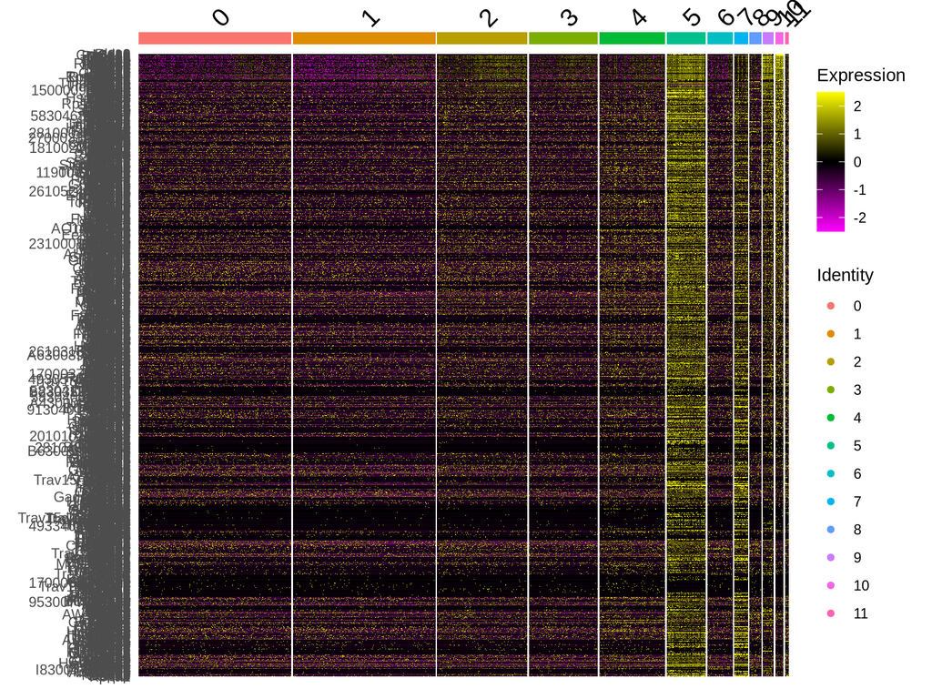

## 6.7 Volcano plot

A Volcano plot is usefull to identify differnetial expression analysis bias.

The package `EnhancedVolcano` has an [eponym](https://bioconductor.org/packages/3.17/bioc/html/EnhancedVolcano.html) function for that:

```r
EnhancedVolcano::EnhancedVolcano(
  #  variable pointing to the DEA results
  toptable = sobj_wilcox,
  # Gene names
  lab = rownames(sobj_wilcox),
  # Column in which to find Fold Change
  x = "avg_log2FC",
  # Column in which to find confidence interval
  y = "p_val_adj",
  # Lower fold-change cut-off
  FCcutoff = 0.2
)
```

**Show plot**

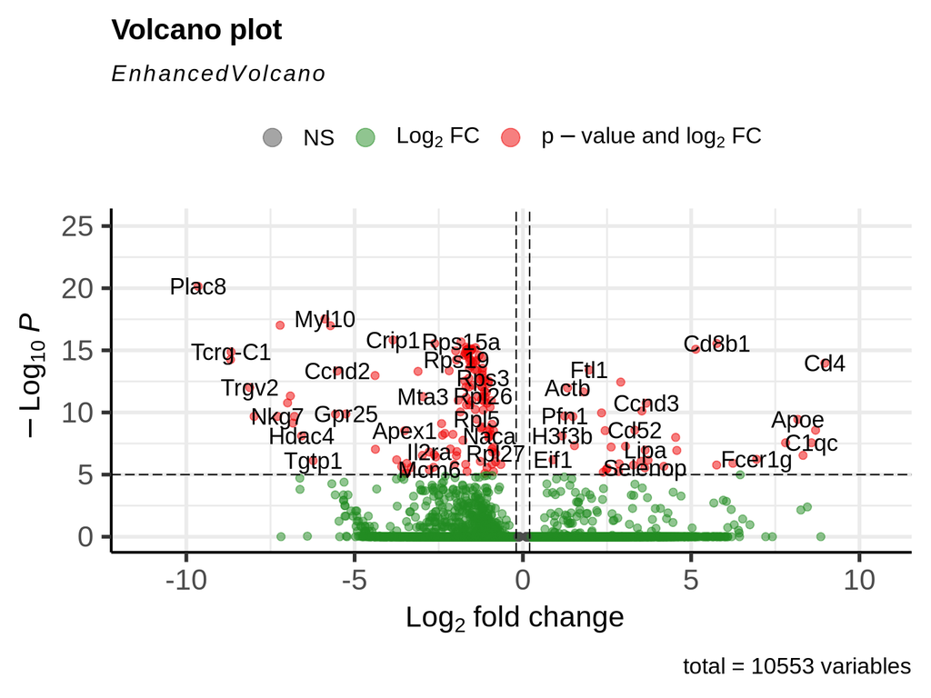